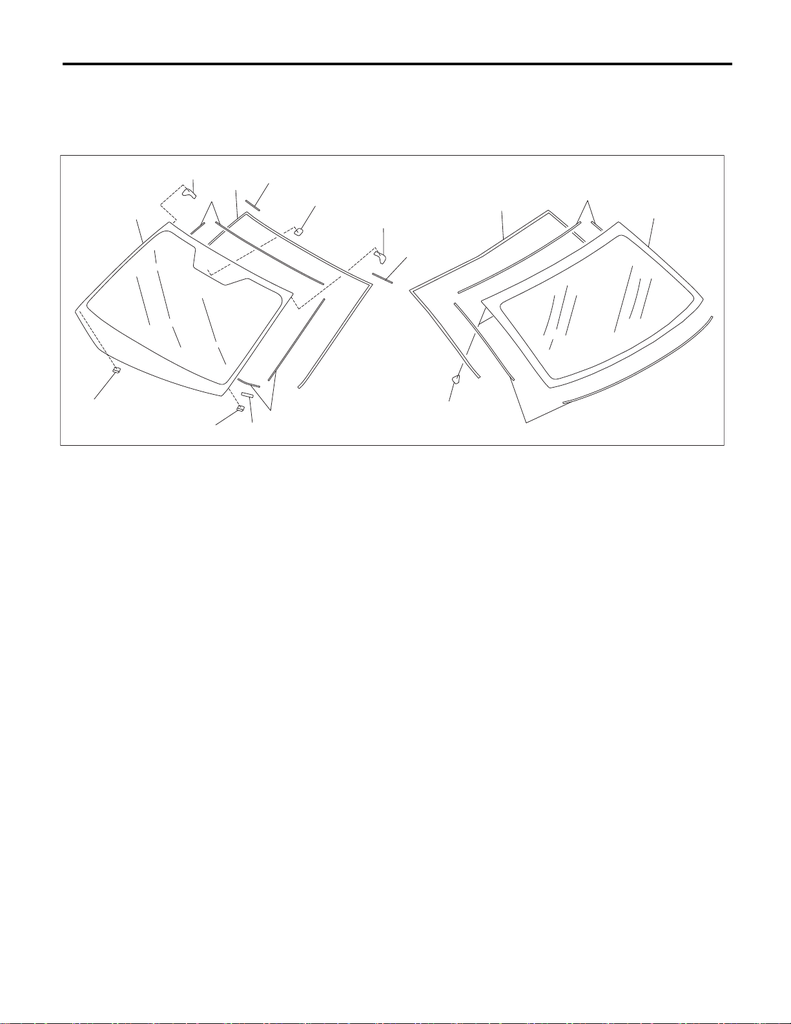

GW-2

General Description

GLASS/WINDOWS/MIRRORS

1. General Description

A: COMPONENT

1. FIXED GLASS

(1) Glass - front window (5) Base - inner mirror (9) Glass - rear window

(2) Dam rubber - front (6) Locating pin - front window (10) Locating pin - rear window

(3) Molding - front window (7) Molding - rear window (11) Seal - lower VIN

(4) Seal - upper (8) Dam rubber - rear (12) Seal - lower

GW-01427

(1)

(2)

(2)

(3)

(4)

(5)

(6)

(6)

(12)

(8)

(7)

(8)

(10)

(9)

(4)

(12)

(11)

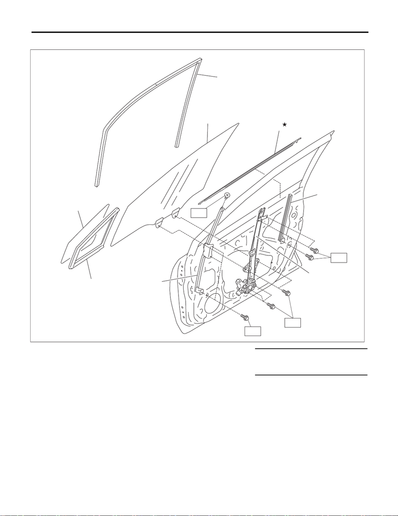

GW-3

General Description

GLASS/WINDOWS/MIRRORS

2. FRONT DOOR GLASS

(1) Running channel - front door (5) Regulator & motor ASSY - front Tightening torque: N·m (kgf-m, ft-lb)

(2) Glass ASSY - front door (6) Sash COMPL - partition T1: 2.2 (0.2, 1.6)

(3) Weather strip outer - front door (7) Weather strip - front door partition T2: 7.5 (0.8, 5.5)

(4) Sash COMPL - lower (8) Glass - front door partition

T2

GW-01059

(2)

(3)

(4)

(5)

(6)

(7)

(8)

T2

T2

T1

(1)

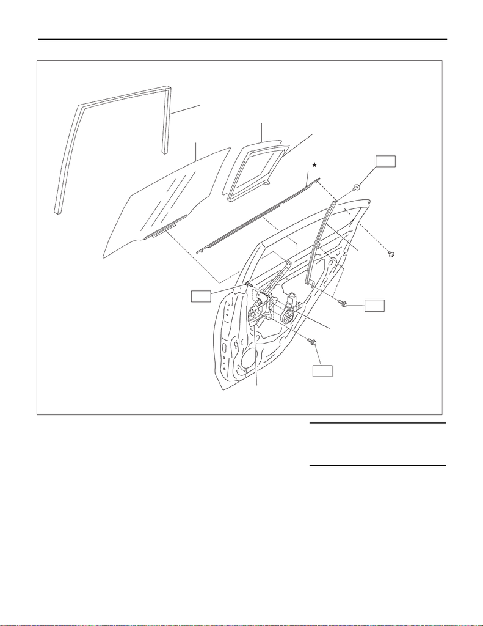

GW-4

General Description

GLASS/WINDOWS/MIRRORS

3. REAR DOOR GLASS

(1) Running channel - rear door (5) Weather strip outer - rear door Tightening torque: N·m (kgf-m, ft-lb)

(2) Glass ASSY - rear door (6) Sash COMPL - rear partition T1: 2.2 (0.2, 1.6)

(3) Glass - rear door partition (7) Motor - rear T2: 5.9 (0.6, 4.4)

(4) Weather strip - rear door partition (8) Regulator - rear T3: 7.5 (0.8, 5.5)

GW-01401

(1)

T3

(2)

(3)

(4)

(5)

(6)

(7)

(8)

T1

T3

T2

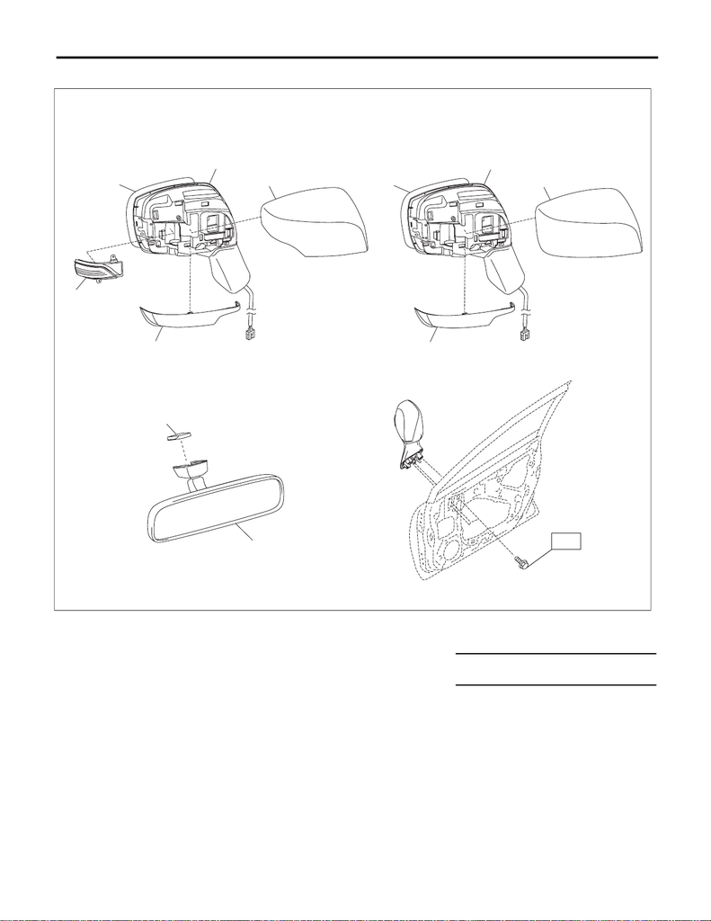

GW-5

General Description

GLASS/WINDOWS/MIRRORS

4. MIRROR

B: CAUTION

• Before disconnecting connectors of sensors or units, be sure to disconnect the ground cable from battery.

When replacing the audio and MFD parts provided with memory functions, record the memory contents be-

fore disconnecting the battery ground cable.

• Avoid impact and damage to the glass.

(A) Model with side turn (B) Model without side turn

(1) Mirror - repair (5) Light ASSY - side turn mirror Tightening torque: N·m (kgf-m, ft-lb)

(2) Mirror unit - door (6) Base - inner mirror T: 7.5 (0.8, 5.5)

(3) Cover - cap outer mirror (7) Mirror ASSY - inner rearview

(4) Cover - cap outer mirror lower

GW-01421

(B)

(A)

(1)

(3)

(5)

(4)

(2)

(6)

(7)

(1)

(3)

(4)

(2)

T

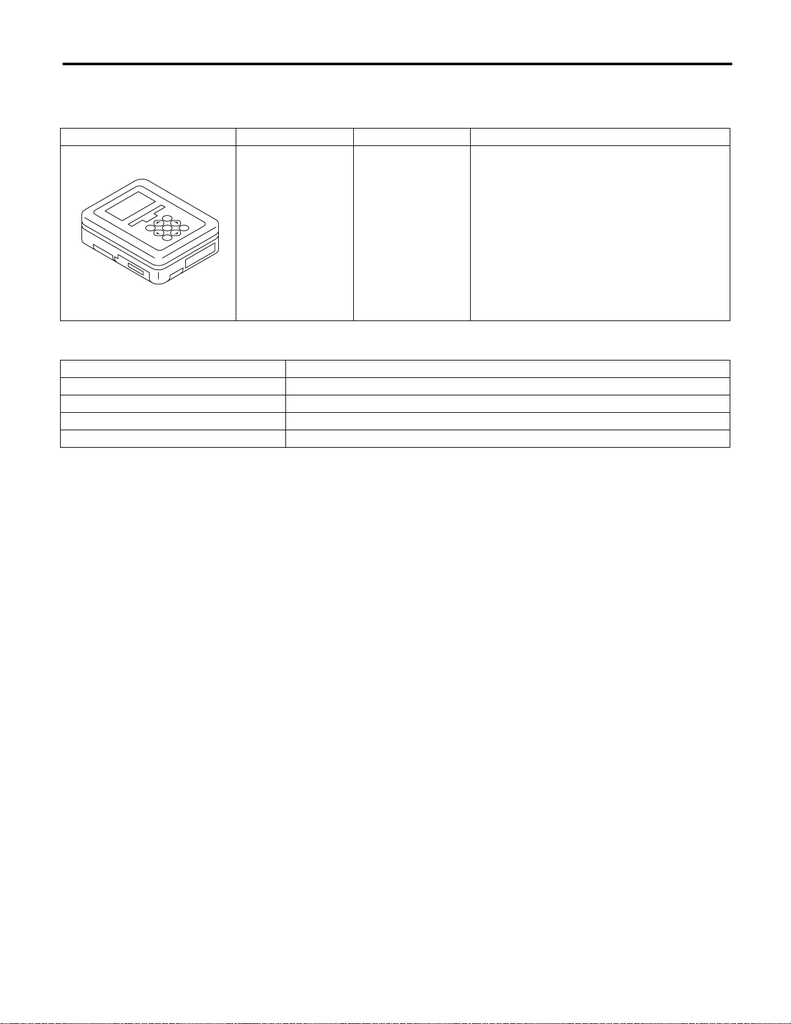

GW-6

General Description

GLASS/WINDOWS/MIRRORS

C: PREPARATION TOOL

1. SPECIAL TOOL

2. GENERAL TOOL

ILLUSTRATION TOOL NUMBER DESCRIPTION REMARKS

1B022XU0 SUBARU SELECT

MONITOR III KIT

Used for setting of each function and trouble-

shooting for electrical system.

TOOL NAME REMARKS

Circuit tester Used for measuring resistance and voltage.

Piano wire Used for removing the window glass.

Cutter knife Used for removing the window glass.

Windshield glass knife Used for removing the window glass.

ST1B022XU0